# E2B, E4B or 12B? On an 8 GB RTX 3050, Serve Gemma 4 E4B

The first instinct on an 8 GB card is to run the biggest Gemma 4 that fits. That is the 12B, and with thinking off it is the most accurate of the three. Serve E4B instead. With thinking on and the sampling settings Google ships with the model, E4B matched the 12B on the first 157 GSM8K problems, 153 right each, in 0.55 hours against 0.96, and it keeps the full 131,072-token context on the card.

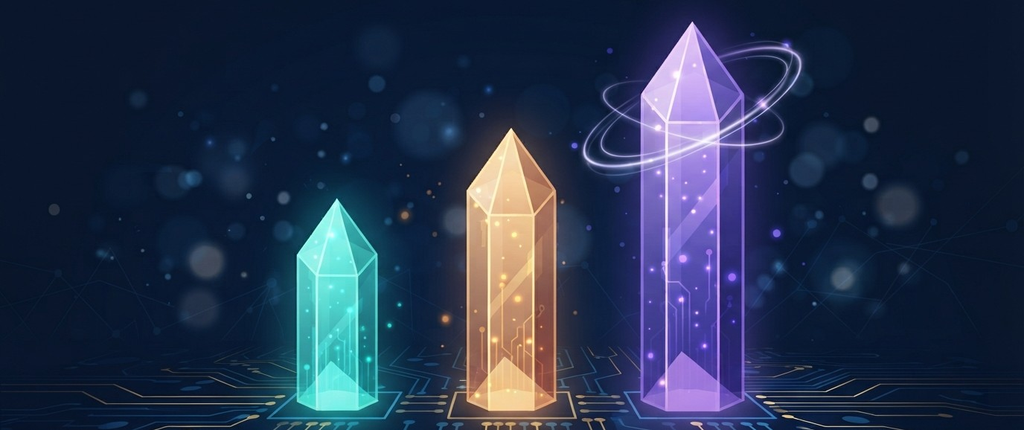

This article provides a step by step comparison of three Gemma 4 models on one local GPU: E2B, E4B and 12B, each as a 4-bit QAT build on an 8 GB RTX 3050 through llama.cpp. It rolls up the [E2B](https://dev.to/gde/thinking-on-or-off-gemma-4-e2b-on-an-8-gb-rtx-3050-30e0) and [E4B](https://dev.to/gde/thinking-on-or-off-gemma-4-e4b-on-an-8-gb-rtx-3050-5d5) articles and adds the 12B, on the same problems and settings, then says which one to serve. Every setting ran at temperature 0, and then again with Google's sampling settings.

https://github.com/xbill9/gemma4-dev/tree/main/docs/gemma4-e2b-e4b-12b-3050

The short version: serve E4B with thinking on and Google's sampling settings. Take E2B when speed or memory comes first, and the 12B with thinking off for hard math or function calls when you can wait longer. Never run the 12B with thinking on at temperature 0: it works out the answer and then argues with the question until it runs out of tokens.

#### The Decision Flow

Answer two questions in order and stop at the first yes.

[figure not shown]

1. **Do you need the fastest replies, or half the card free?** Use **E2B**: 3,610 MiB with the full context and 3.72 seconds per GSM8K problem, for the lowest scores of the three.
2. **Is it hard math or function calls, and can you wait longer?** Use the **12B with thinking off**. With Google's settings it solved 19 of 30 AIME problems against 15 for E4B with thinking on, in 3.07 times the time; that gap is within chance, and against E4B with thinking off (10 of 30) it is beyond chance. On function calls (BFCL simple, 400 problems, temperature 0, October runs) it scored 0.9500 against E4B's 0.9125, a paired gain of +0.0375 with a 95% range of +0.0100 to +0.0650, above zero.
3. **Otherwise** use **E4B with thinking on and Google's settings**: 153 of 157 GSM8K problems, level with the 12B, no reply at the token limit, and the full 131,072-token context in 6,430 MiB.

#### The Findings

**Thinking off, bigger scores higher.** GSM8K 0.9014 for E2B, 0.9295 for E4B and 0.9621 for the 12B; each step is beyond chance on a paired test (p = 0.00039 and p = 8.91e-7). AIME 2025: 7, 12 and 15 of 30.

**Bigger is slower.** A full GSM8K pass took 1.36, 2.38 and 6.10 hours. The 12B took 2.56 times as long as E4B for 43 more problems.

**Thinking on at temperature 0, E2B and E4B: no change.** GSM8K moved by −11 and +4 problems, both within chance, for 2.31 and 2.29 times the time.

**Thinking on at temperature 0, 12B: it falls apart.** On the first 157 GSM8K problems it got 87 right against 152 with thinking off, and 70 replies ran to the 32,768-token limit. In 61 of those 70 the thinking had already written the right answer, around token 333.

**Why.** At temperature 0 the model always takes the most likely next token. The 12B second-guesses the wording of the question and repeats the same block of doubt until the limit; an f16 cache loops the same way. With Google's recommended sampling settings the loops stop.

**With Google's settings, the 12B's lead closes.** Temperature 1.0, top-k 64 and top-p 0.95, from each model's `generation_config.json`. On the first 157 GSM8K problems E4B with thinking on got 153, the 12B with thinking off 153 and with thinking on 151, all level. E4B's 153 is beyond chance over its own 146 with thinking off at temperature 0 (p = 0.0156). The 12B with thinking on no longer loops, and takes 5.30 times as long as with it off.

**What to do with it.**

- 🟢 E4B with thinking on and Google's settings is the default: level with the 12B on GSM8K in 0.57 times its time, the full 131,072-token context, 0 of 11,009 replies at the token limit.
- 🟢 The 12B with thinking off is the most accurate of the three at temperature 0, and the largest Gemma 4 that fits entirely on the card.
- ❌ The 12B with thinking on at temperature 0 is unusable.

#### What Was Measured

The same run three times, once per model, on one card:

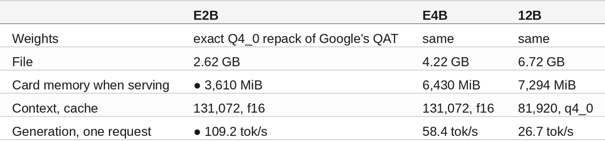

Each model answered all 1,319 GSM8K test problems and the 30 problems of AIME 2025, with thinking off and on, one request at a time, at temperature 0, with a 32,768-token limit on each reply, thinking included. E2B and E4B also ran Google's own QAT file and a drafter; those results are in their own articles. The 12B ran the repack without a drafter, and its GSM8K thinking-on run was stopped at 157 problems. A second set ran Google's sampling settings, without a drafter: AIME with thinking off and on for all three, the first 157 GSM8K problems with thinking on for all three and off for the 12B, and the 12B's AIME with thinking on twice.

#### At This Point You Should Have…

- An NVIDIA card with 8 GB, here an RTX 3050 OEM on driver 615.78.08
- llama.cpp built with CUDA, here commit `7182ef71e`
- Python 3
- A clone of gemma4-dev

#### Step 1 — Fitting Three Sizes on 8 GB

E2B and E4B fit with room to spare: the full 131,072-token context at f16 takes 3,610 and 6,430 MiB. The 12B's weights alone are 6.72 GB, so its context cache has to shrink to 4 bits (q4_0) to hold 81,920 tokens in 7,294 MiB. A 4-bit cache scored level with f16 on GSM8K in an earlier 12B run, and the loop test in Step 5 ran both caches.

#### Step 2 — Thinking Off: Scores and Time

**GSM8K, 1,319 problems, thinking off**

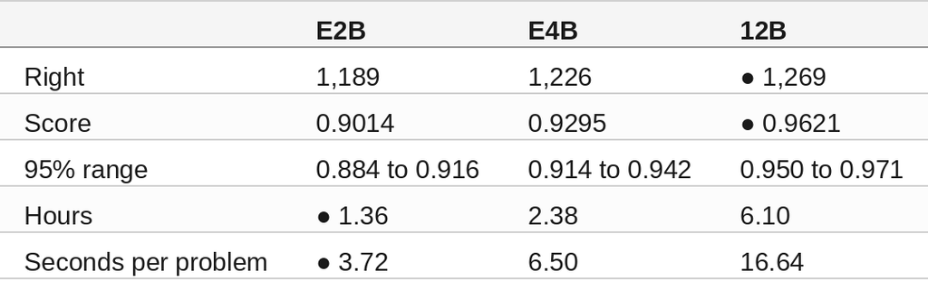

**AIME 2025, 30 problems, thinking off**

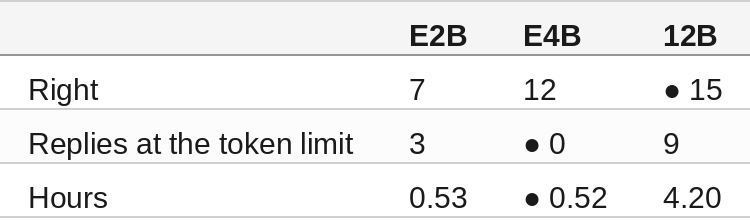

The 12B reached 15 of 30 on AIME with 9 replies cut off at the limit, 6 of them repeating the same block of text, so even with thinking off it can loop on hard problems.

#### Step 3 — Is Each Step Up Bigger Than Chance?

The same problems ran for every model, so each comparison is an exact paired test on the problems one model got right and the other got wrong.

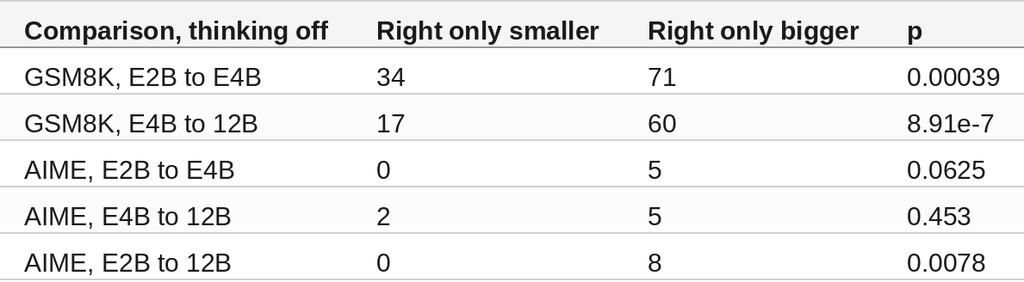

On GSM8K both steps hold. On AIME only the jump from E2B to the 12B does; 30 problems are too few to separate neighbours.

#### Step 4 — Thinking On

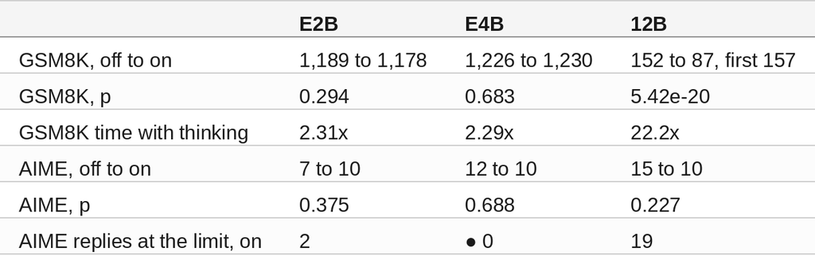

For E2B and E4B thinking doubled the time and moved no score beyond chance. For the 12B it lost 65 GSM8K problems and gained none. Every one of its 87 replies that stopped on its own was right; the other 70 hit the limit and never wrote an answer.

On the same first 157 problems with thinking on, E4B got 148 and E2B 142.

#### Step 5 — Why the 12B Falls Apart

`why.py` reads the 70 GSM8K replies that hit the limit:

- In 61 of 70 the thinking writes `= <the right answer>`, at about token 333 (median).
- From about token 1,985 a block of about 1,094 tokens repeats until the limit (medians).
- The last 3,000 characters of 55 of the 70 re-read the wording: "Could it mean…", "Let's think about the wording … again".
- None of the 70 writes its final `Answer:` line.

The same 70 problems for the smaller models, thinking on:

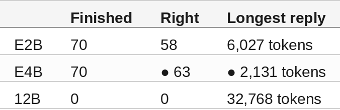

Then the first 8 of those problems again, changing the cache, then the sampling:

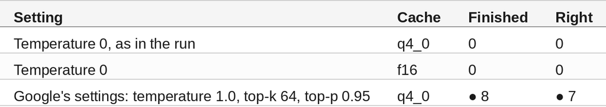

On these 8 problems the cache made no difference; greedy decoding (temperature 0) is what keeps the 12B in the loop. The likely mechanism: once a block of doubt has repeated, the same block again is the most likely next text, and temperature 0 always takes it, while sampling can pick a different token and leave. The sampled replies took 1,596 to 11,894 tokens. Step 6 runs the full sets this way.

#### Step 6 — Google's Sampling Settings

Each model's `generation_config.json` sets temperature 1.0, top-k 64 and top-p 0.95. The same problems again with those settings, one run each, no drafter:

**GSM8K, first 157 problems**

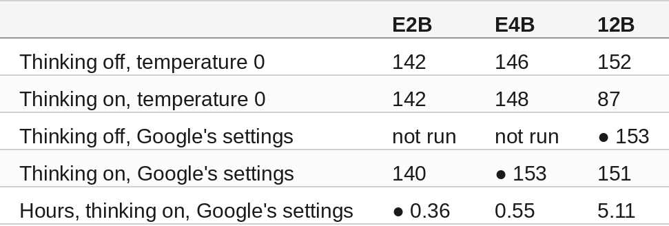

- **E4B:** thinking on with Google's settings against thinking off at temperature 0: +7 / −0, p = 0.0156, for 2.01 times the time. Two things changed at once, sampling and thinking; E4B with thinking off and Google's settings was not run on GSM8K.
- **12B:** thinking on with Google's settings against at temperature 0: +65 / −1, p = 1.82e-18, and 0 of 157 replies at the limit. Against thinking off with Google's settings it is level (p = 0.688) at 5.30 times the time.
- **E4B with thinking on against the 12B with thinking off, both Google's settings:** 153 each, 1 problem only E4B got and 1 only the 12B got (p = 1). The 12B took 1.75 times as long.
- **E2B:** no change beyond chance (p = 0.804).

157 problems are too few to show a gap as small as the 12B's lead over E4B on all 1,319. At temperature 0 with thinking off, the 12B's 3.3-point lead on the full set is beyond chance (p = 8.91e-7), but on these same 157 it is 152 against 146, +8 / −2, within chance (p = 0.109). So "level" here means no difference was found on 157 problems.

**AIME 2025, 30 problems, Google's settings**

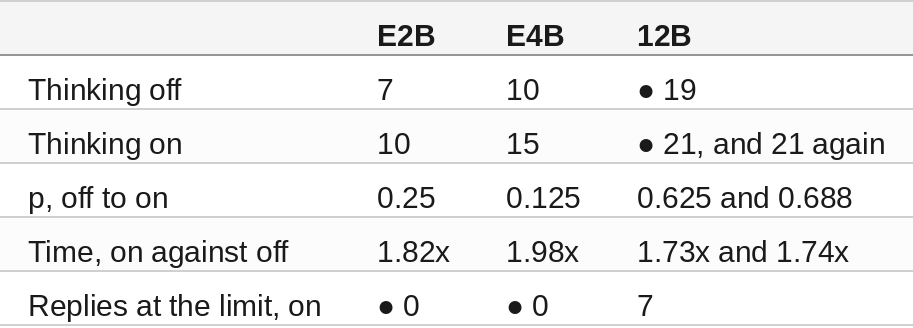

With thinking off the 12B leads E4B beyond chance (19 against 10, +9 / −0, p = 0.0039). E4B with thinking on narrows that to 15 against 19, within chance (p = 0.219), in 0.33 times the 12B's time. The 12B with thinking on at temperature 0 got 10; with Google's settings 21, beyond chance (p = 0.0074).

Across every run with Google's settings, E2B and E4B hit the token limit in 0 of 217 replies each, the 12B in 20 of 404.

#### Step 7 — The Drafter

Each model has a small QAT drafter from Google that guesses the next two tokens for the main model to check in one step. From the earlier runs on this card:

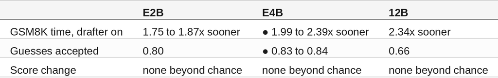

The 12B figures come from its October run: GSM8K with thinking off, an f16 cache at 24,576 tokens, 0.9598 with the drafter and 0.9629 without, and 0.658 acceptance on six chat prompts. The drafter pays on every model and costs nothing in answers. These drafter figures are at temperature 0; with Google's sampling settings the drafter is untested here.

#### 🔎 Tip: Copy the Model's Sampling Settings Before You Turn Thinking On

Benchmarks usually run at temperature 0 so the results repeat. For the 12B with thinking on, that setting is what breaks it: 87 of 157 on GSM8K at temperature 0, 151 with Google's `generation_config.json` settings (temperature 1.0, top-k 64, top-p 0.95). Read the model's settings before you serve it with thinking on, and check how many replies hit your token limit: a looping model shows up there before it shows up anywhere else.

#### Compare and Contrast

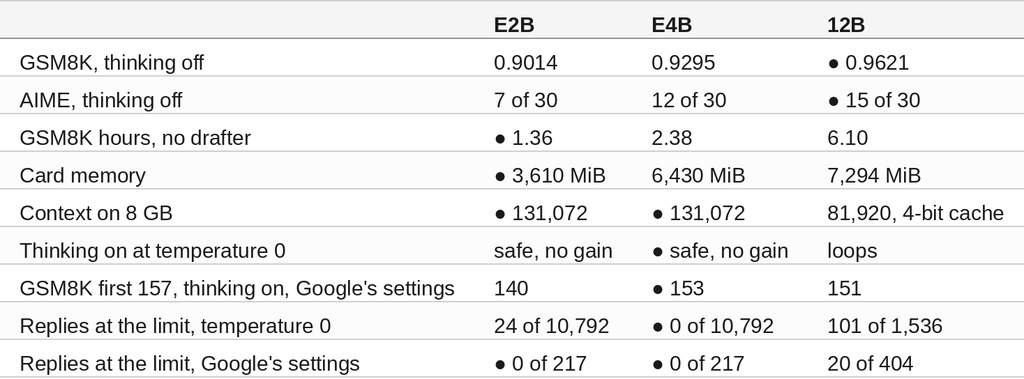

**Pros and cons**

- **E2B.** 🟢 Fastest, smallest, the full context in 3,610 MiB. ❌ Lowest scores: 37 fewer GSM8K problems than E4B and 80 fewer than the 12B.
- **E4B.** 🟢 With thinking on and Google's settings, level with the 12B on GSM8K in 0.57 times its time. 🟢 Never hit the token limit, in 11,009 replies. 🟢 The best drafter gain, up to 2.39x. 🟢 The full context. ⚠️ 1.75 times E2B's time.
- **12B.** 🟢 The most right answers with thinking off, beyond chance over E4B. 🟢 The most AIME problems with Google's settings, 19 and 21 of 30. 🟢 Function calls: 0.9500 on BFCL against E4B's 0.9125, beyond chance (October runs). ❌ 2.56 times E4B's time and 7,294 MiB of the card's 8 GB. ❌ Loops at temperature 0 with thinking on, and on some hard problems with it off.

#### So, Which One?

**Default: E4B with thinking on and Google's sampling settings.** The 12B is the largest model that fits and the most accurate with thinking off, so it looks like the pick. Run E4B the way Google ships it and it matched the 12B on the first 157 GSM8K problems in 0.57 times the time, never hit the token limit, and kept the full 131,072-token context with 1,762 MiB of the card to spare. With thinking off it is the 0.9295 model, and its drafter makes it about twice as fast.

**Hard math or function calls, when you can wait: the 12B with thinking off.** It answered 60 GSM8K problems E4B missed and missed 17 E4B answered, both at temperature 0, led AIME with Google's settings, and scored 0.9500 on function calls against E4B's 0.9125. Serve it with its drafter.

**Smallest and fastest: E2B.** It uses 3,610 MiB and answers in 3.72 seconds per GSM8K problem.

**Thinking: match it to the sampling.** At temperature 0 it doubled the time on E2B and E4B for no change beyond chance, and broke the 12B. With Google's settings it is safe on all three, and E4B with it went from 146 to 153 of 157 against thinking off at temperature 0, beyond chance.

#### Summary

The goal of this article was to compare Gemma 4 E2B, E4B and 12B on one 8 GB card and say which to serve. The key to the solution was running all three on the same 1,349 problems with the same settings, so every comparison is paired problem by problem. The results were:

- 🟢 E4B with thinking on and Google's sampling settings matched the 12B on the first 157 GSM8K problems, 153 each, in 0.55 hours against 0.96; 157 problems are too few to show a gap of a few points.
- 🟢 The 12B leads on function calls: 0.9500 on BFCL against E4B's 0.9125 (October runs).
- 🟢 Thinking off at temperature 0, every step up in size scored higher on GSM8K beyond chance: 0.9014, 0.9295, 0.9621.
- ⚠️ Every step up in size took longer: 1.36, 2.38 and 6.10 hours for GSM8K.
- ⚠️ At temperature 0, thinking doubled the time on E2B and E4B and changed no score beyond chance.
- ❌ At temperature 0, the 12B with thinking on loops: 70 of 157 GSM8K replies hit the limit, 61 of them after writing the right answer.
- 🟢 Google's sampling settings stopped the loop: the 12B with thinking on got 151 of 157, level with thinking off, at 5.30 times the time; the cache type made no difference.
- 🟢 The drafter made every model 1.75 to 2.39 times faster on GSM8K and changed no score.

Scope: one RTX 3050 OEM with 8 GB in one desktop, llama.cpp `7182ef71e`, one run of each setting, exact Q4_0 repacks of Google's QAT weights, temperature 0 unless stated, one request at a time, a 32,768-token reply limit, 2026-11-16 to 22. GSM8K is all 1,319 test problems and AIME 2025 is papers I and II. The 12B's GSM8K thinking-on run covers the first 157 problems. The runs with Google's sampling settings are one seed each (two for the 12B's AIME with thinking on), cover 157 GSM8K problems, and ran without a drafter; E2B and E4B with thinking off ran AIME only. Function-call scores come from October runs at temperature 0 with thinking off: the 12B on llama.cpp `7182ef71e` at 24,576 tokens, E4B on `77c4540ce` at 131,072; BFCL with Google's settings is untested. The 12B's drafter figures come from an October run with a different cache and context. Times move with clock and temperature. The 26B and 31B also run on this card with part of the model in system RAM; they are outside this comparison.

The strategy for choosing a Gemma 4 size for a small GPU was validated with an incremental step by step approach.

#### References

- [gemma4-dev on GitHub](https://github.com/xbill9/gemma4-dev)
- [This article's evidence: scripts and outputs](https://github.com/xbill9/gemma4-dev/tree/main/docs/gemma4-e2b-e4b-12b-3050/evidence)
- [The 12B run: replies and logs](https://github.com/xbill9/gemma4-dev/tree/main/local-llamacpp-3050oem-12b-q4_0/benchmarks/runs/2026-11-17-thinking-12b-3050oem)
- [The 12B loop test](https://github.com/xbill9/gemma4-dev/tree/main/local-llamacpp-3050oem-12b-q4_0/benchmarks/runs/2026-11-20-thinking-loops-12b-3050oem)
- [Google's sampling settings, 12B](https://github.com/xbill9/gemma4-dev/tree/main/local-llamacpp-3050oem-12b-q4_0/benchmarks/runs/2026-11-21-drafter-sampling-12b-3050oem)
- [Google's sampling settings, all three](https://github.com/xbill9/gemma4-dev/tree/main/local-llamacpp-3050oem-12b-q4_0/benchmarks/runs/2026-11-22-sampling-e2b-e4b-12b-3050oem)
- [Thinking On or Off? Gemma 4 E2B on an 8 GB RTX 3050](https://dev.to/gde/thinking-on-or-off-gemma-4-e2b-on-an-8-gb-rtx-3050-30e0)
- [Thinking On or Off? Gemma 4 E4B on an 8 GB RTX 3050](https://dev.to/gde/thinking-on-or-off-gemma-4-e4b-on-an-8-gb-rtx-3050-5d5)
- [The scoring script](https://github.com/xbill9/gemma4-dev/tree/main/benchmarks/gen-eval)
- [Exact Q4_0 repack of Gemma 4 12B QAT](https://huggingface.co/xbill9/gemma-4-12B-it-qat-q4_0-exact-gguf)
- [Exact Q4_0 12B QAT drafter](https://huggingface.co/xbill9/gemma-4-12B-it-qat-assistant-q4_0-exact-gguf)
- llama.cpp

Hope you enjoyed it!